# Time Series and Panel Data Model

Nhat My Thien Nguyen

4/30/2021

```r
knitr::opts_chunk$set(echo = TRUE)
library(PoEdata); library(xtable); library(knitr); library(lmtest); library(zoo);library(carData);library(sandwich);library(ggplot2);library(gridExtra);library(lmtest);library(readxl);library(car);library(stargazer);library(lattice);library(survival);library(Formula);library(nortest);library(foreign);library(nnet);library(reshape2);library(readxl); library(kableExtra); library(xtable); library(knitr); library("tidyr");library(tidyverse);library(broom);library(AER); library(systemfit); library(nnet); library(censReg); library(truncreg); library(dynlm);library(orcutt); library(nlWaldTest);library(pdfetch); library(forecast); library(TTR); library(tseries); library(plm)
```

# Problem 4

```r
accidents<-read_excel("AccidentsTS.xls")
```

1. Use the best forecasting method applicable to predict the Total, Fatal and Injury Accidents for the first three months of the year 1990

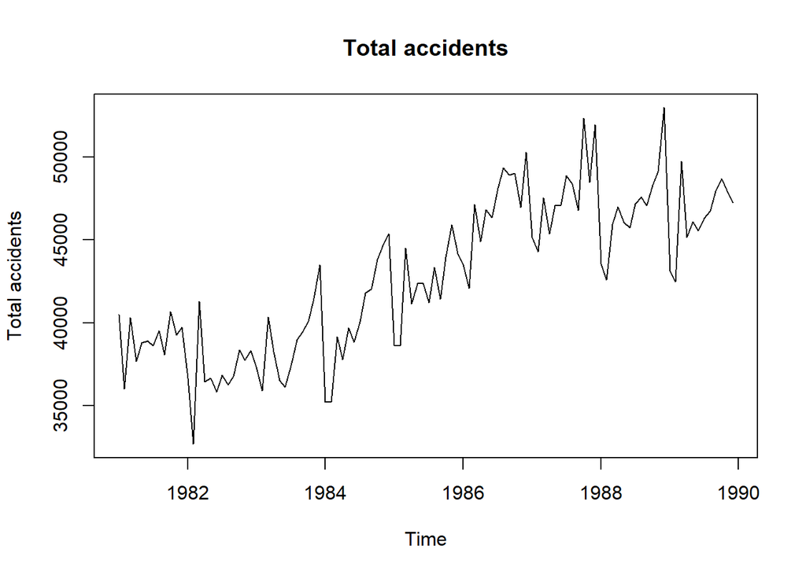

```r
total<-ts(accidents$Tot_Acc,start=c(1981,1),frequency=12)
plot.ts(total,main="Total accidents",ylab="Total accidents",xlab="Time")
```

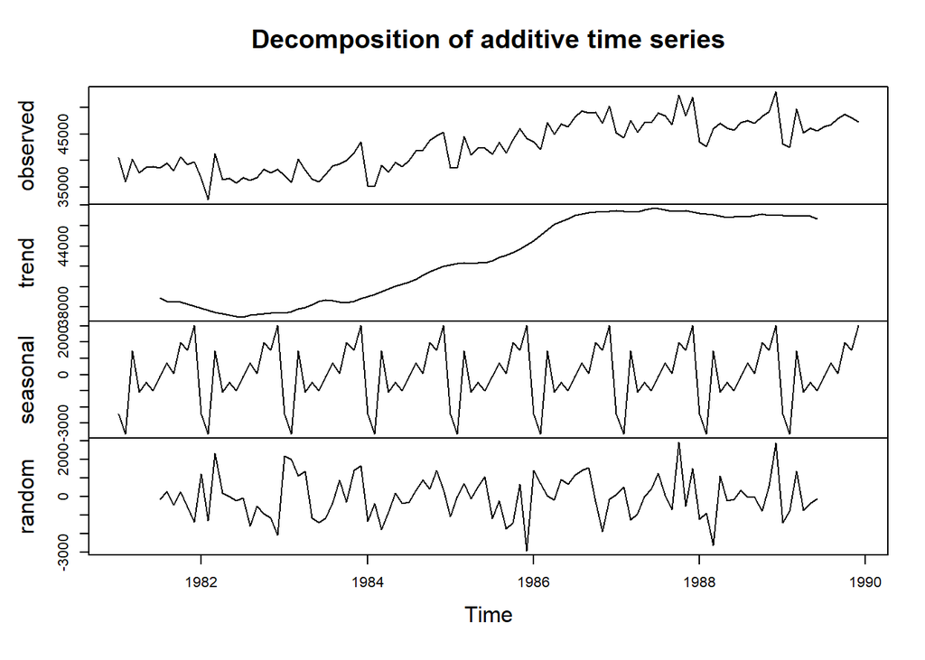

```r
totalcomponents<-decompose(total)
plot(totalcomponents)
```

We can see total accidents have both trend and seasonality, so I will forecast from HoltWinters with both.

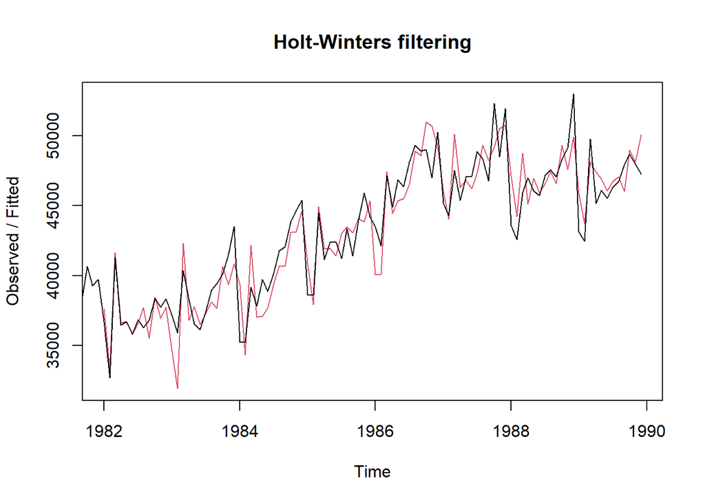

```r
total.HW<- HoltWinters(total)
plot(total.HW)
```

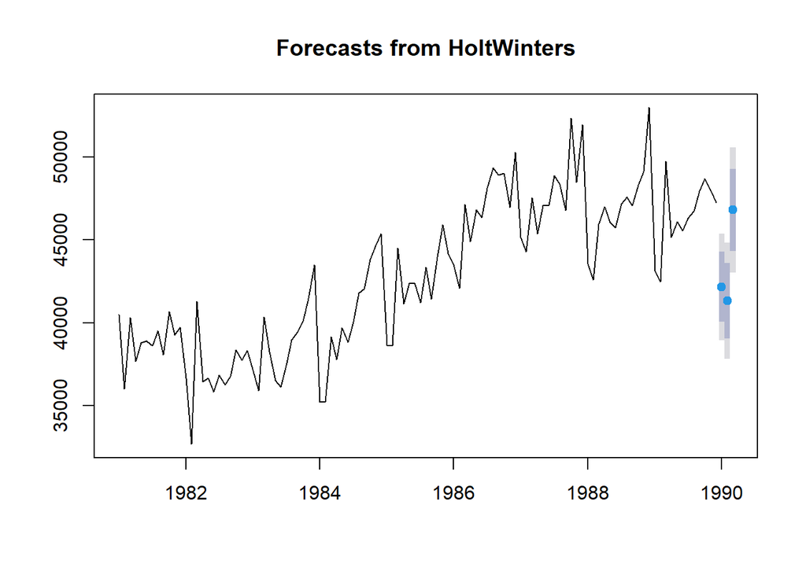

```r
total.HW.forecast<-forecast(total.HW,3)
plot(total.HW.forecast)
```

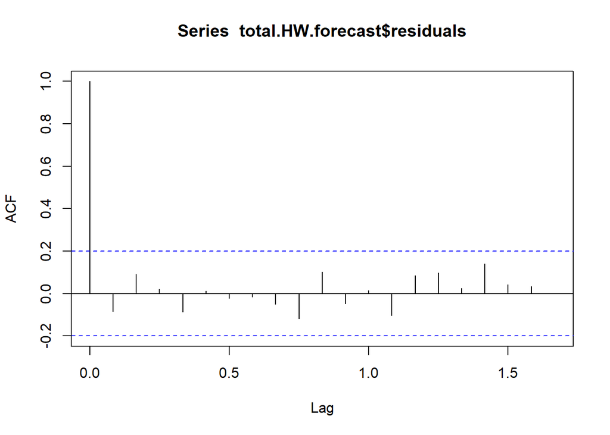

```r
acf(total.HW.forecast$residuals, lag.max=20, na.action = na.contiguous)
```

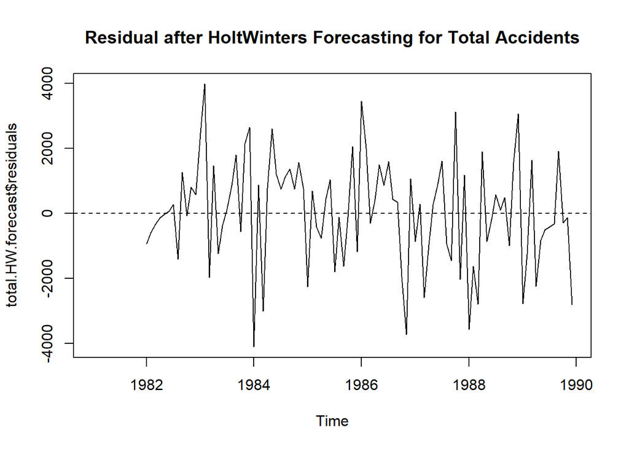

```r
plot.ts(total.HW.forecast$residuals, main="Residual after HoltWinters Forecasting for Total Accidents")
abline(h=0,lty=2)
```

```r
Box.test(total.HW.forecast$residuals,lag=20,type="Ljung-Box")
```

```
##
##  Box-Ljung test
##
## data:  total.HW.forecast$residuals
## X-squared = 11.509, df = 20, p-value = 0.9319
```

### Compare with ARIMA

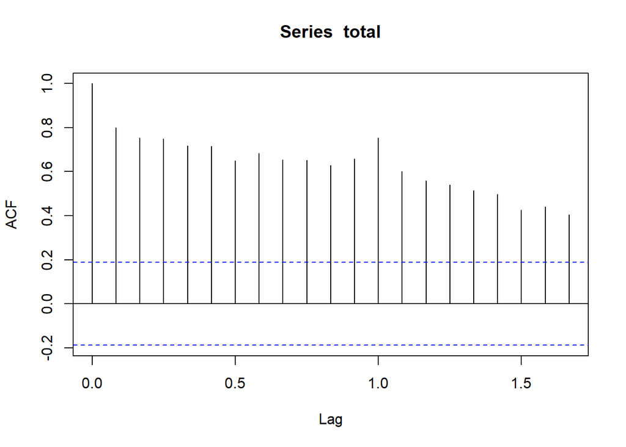

```r
acf(total, lag.max=20)
```

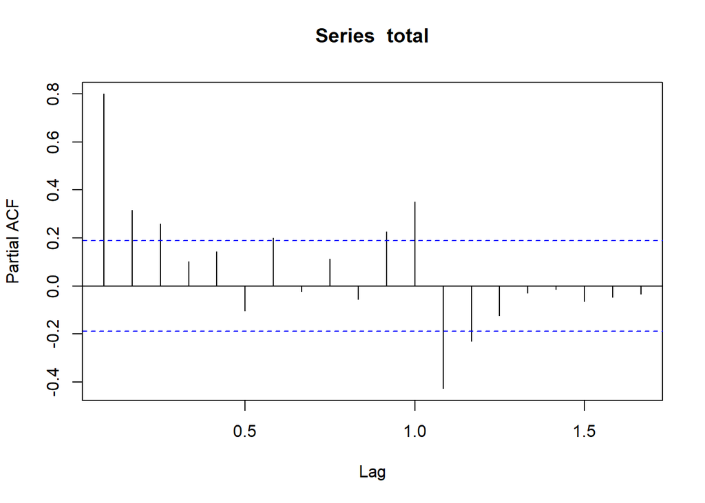

```r
pacf(total, lag.max=20)
```

```r
auto.arima(total)
```

```
## Series: total
## ARIMA(2,1,0)(2,1,1)[12]
##
## Coefficients:
##           ar1      ar2     sar1     sar2     sma1
##       -0.5767  -0.2303  -0.0356  -0.3411  -0.8377
## s.e.   0.1059   0.1092   0.1777   0.1406   0.3677
##
## sigma^2 estimated as 2216982:  log likelihood=-837.68
## AIC=1687.36   AICc=1688.32   BIC=1702.69
```

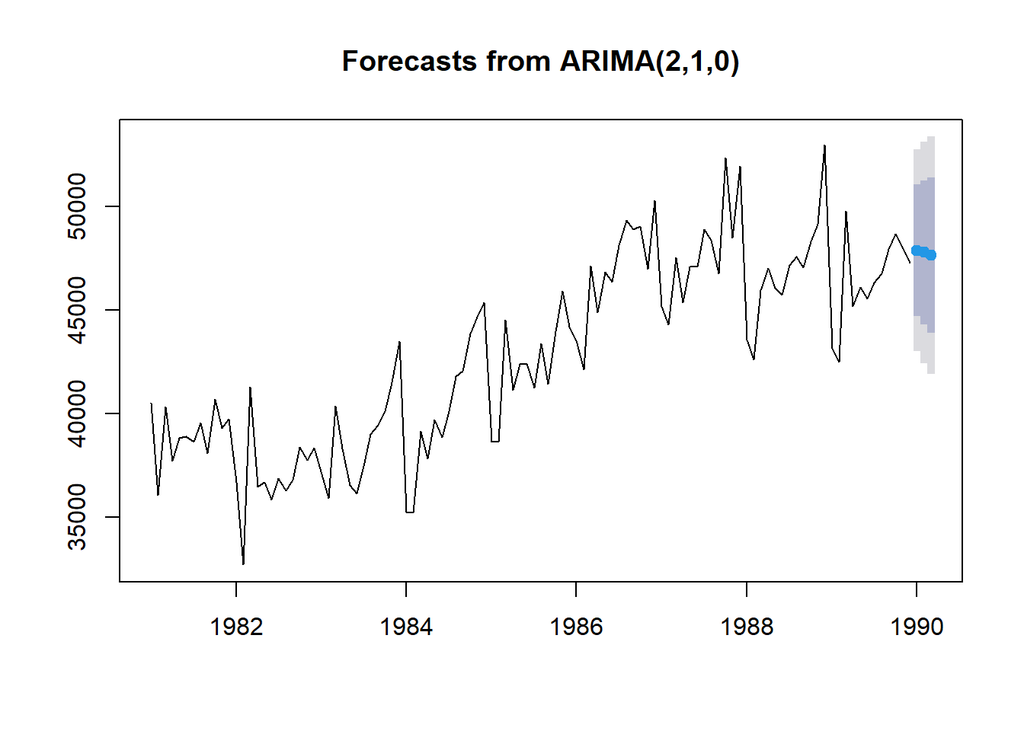

```r
total.ARIMA<-arima(total,order=c(2,1,0))
total.ARIMA.forecast<-forecast(total.ARIMA,3)
plot(total.ARIMA.forecast)
```

```r
Box.test(total.ARIMA.forecast$residuals,lag=20,type="Ljung-Box")
```

```
##
##  Box-Ljung test
##
## data:  total.ARIMA.forecast$residuals
## X-squared = 69.134, df = 20, p-value = 2.521e-07
```

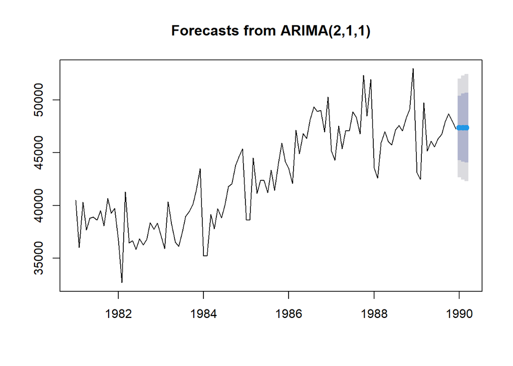

```r
total.ARIMA2<-arima(total,order=c(2,1,1))
total.ARIMA.forecast2<-forecast(total.ARIMA2,3)
plot(total.ARIMA.forecast2)
```

```r
Box.test(total.ARIMA.forecast2$residuals,lag=20,type="Ljung-Box")
```

```
##
##  Box-Ljung test
##
## data:  total.ARIMA.forecast2$residuals
## X-squared = 56.295, df = 20, p-value = 2.624e-05
```

```r
accuracy(total.HW.forecast)
```

```
##                   ME     RMSE      MAE       MPE     MAPE      MASE        ACF1
## Training set 51.9914 1630.473 1294.189 0.1016814 3.010109 0.5927328 -0.08364713
```

```r
accuracy(total.ARIMA.forecast)
```

```
##                  ME     RMSE      MAE        MPE     MAPE      MASE        ACF1
## Training set 134.82 2466.819 1850.392 0.05912723 4.391403 0.8474714 -0.05592308
```

```r
accuracy(total.ARIMA.forecast2)
```

```
##                    ME     RMSE      MAE       MPE     MAPE     MASE        ACF1
## Training set 283.4498 2375.526 1825.203 0.3851938 4.289772 0.835935 -0.01322033
```

As seen, the HoltWinters does better in forecasting than two ARIMA, so we can use HoltWinters to forecast Total Accidents for the first three months of the year 1990

```r
total.HW.forecast
```

```
##          Point Forecast    Lo 80    Hi 80    Lo 95    Hi 95
## Jan 1990       42176.60 40077.16 44276.04 38965.79 45387.41
## Feb 1990       41336.98 39055.25 43618.72 37847.37 44826.60
## Mar 1990       46804.10 44336.20 49271.99 43029.78 50578.42
```

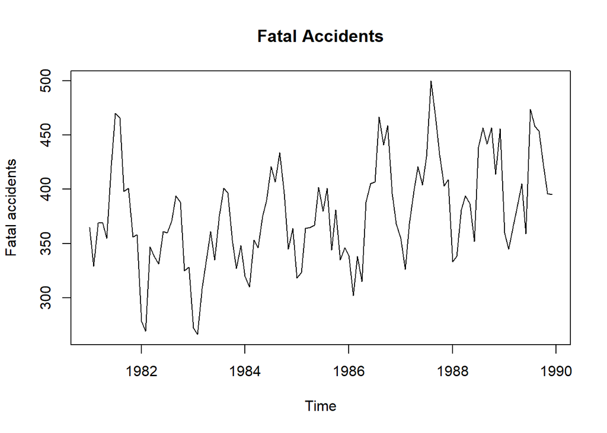

```r
fatal<-ts(accidents$Fat_Acc,start=c(1981,1),frequency=12)
plot.ts(fatal,main="Fatal Accidents",ylab="Fatal accidents",xlab="Time")
```

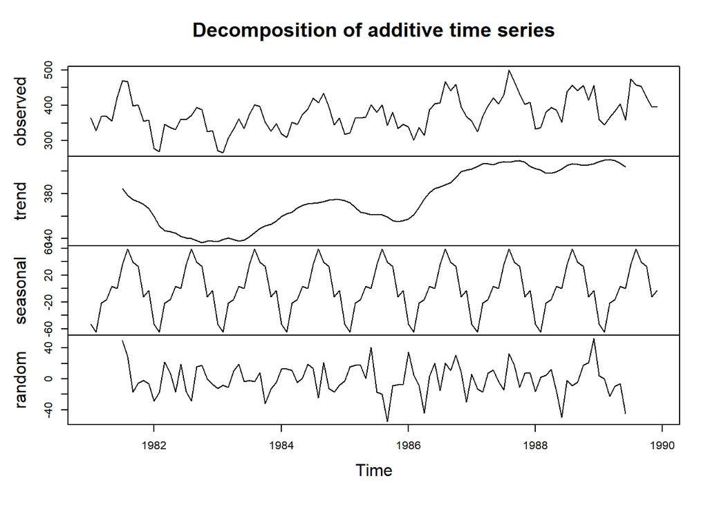

```r
fatalcomponents<-decompose(fatal)
plot(fatalcomponents)
```

We can see fatal accidents have both trend and seasonality, so I will forecast from HoltWinters with both.

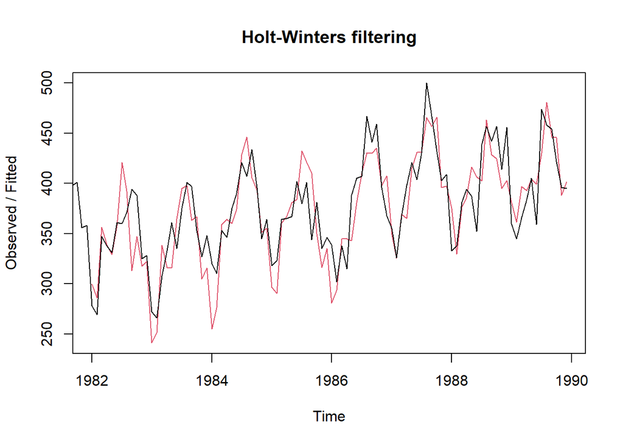

```r
fatal.HW<- HoltWinters(fatal)
plot(fatal.HW)
```

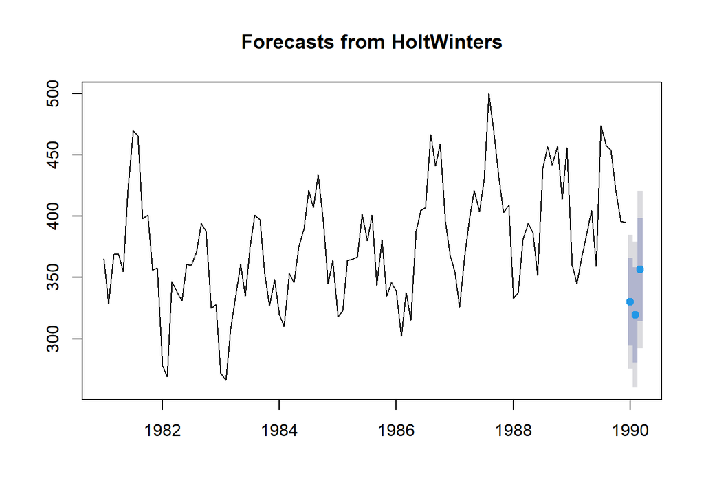

```r
fatal.HW.forecast<-forecast(fatal.HW,3)
plot(fatal.HW.forecast)
```

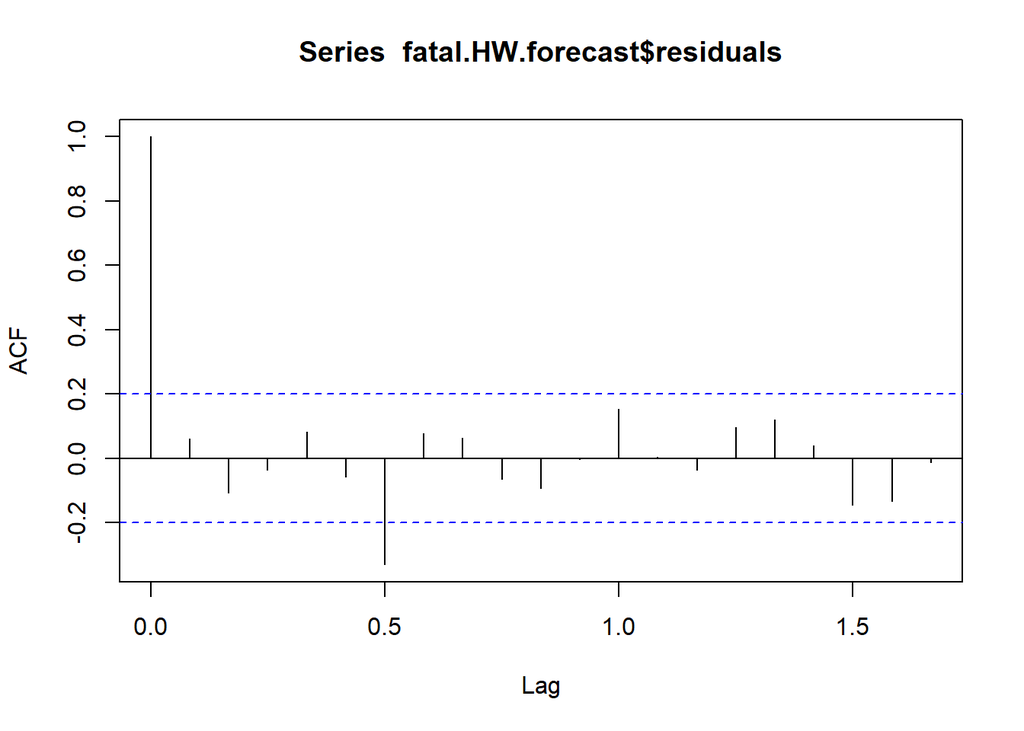

```r
acf(fatal.HW.forecast$residuals, lag.max=20, na.action = na.contiguous)
```

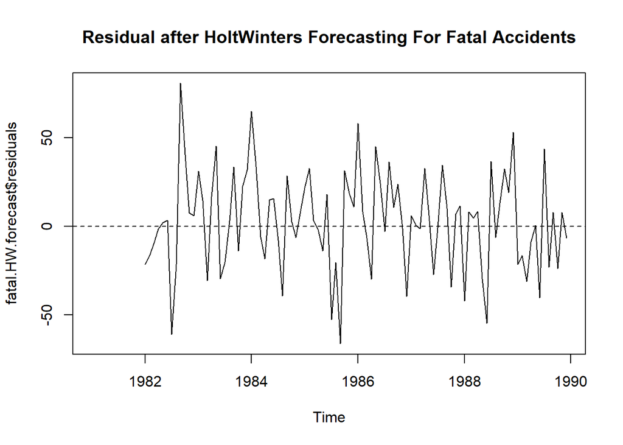

```r
plot.ts(fatal.HW.forecast$residuals, main="Residual after HoltWinters Forecasting For Fatal Accidents")
abline(h=0,lty=2)
```

```r
Box.test(fatal.HW.forecast$residuals,lag=20,type="Ljung-Box")
```

```
##
##  Box-Ljung test
##
## data:  fatal.HW.forecast$residuals
## X-squared = 27.01, df = 20, p-value = 0.135
```

### Compare with ARIMA

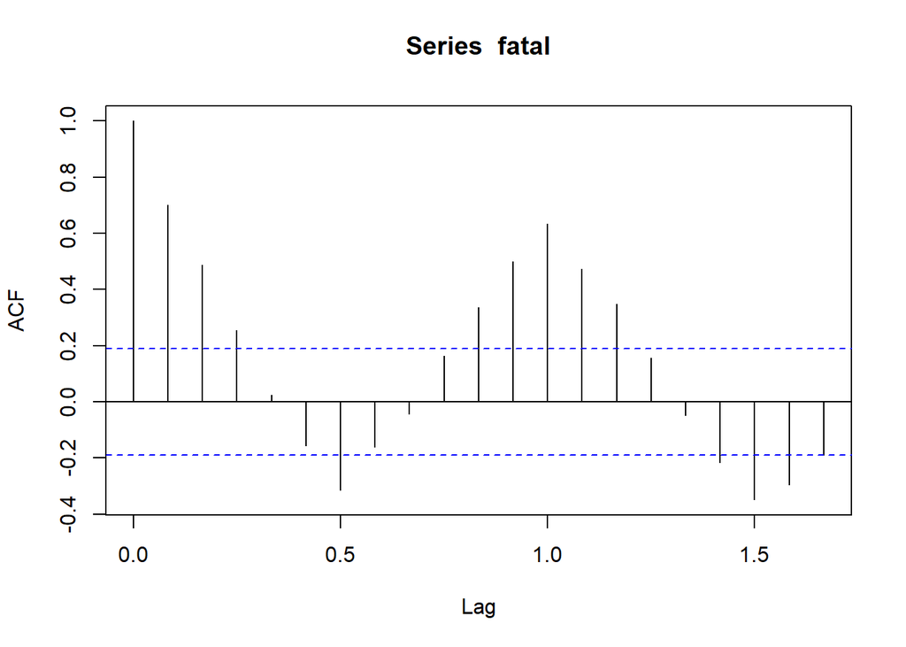

```r
acf(fatal, lag.max=20)
```

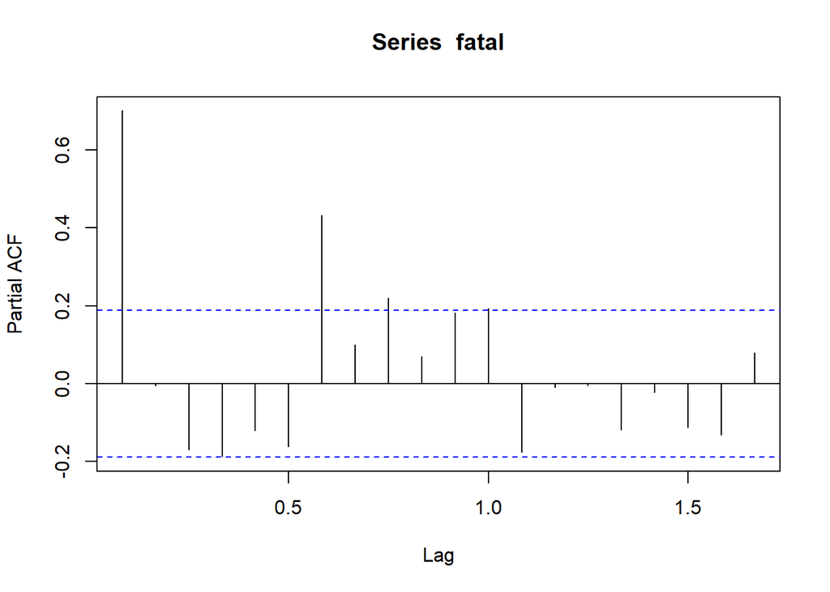

```r
pacf(fatal, lag.max=20)
```

```r
auto.arima(fatal)
```

```
## Series: fatal
## ARIMA(1,0,1)(2,1,0)[12]
##
## Coefficients:
##          ar1      ma1     sar1     sar2
##       0.8870  -0.4961  -0.4432  -0.2944
## s.e.  0.0863   0.1664   0.1158   0.1125
##
## sigma^2 estimated as 769.1:  log likelihood=-455.2
## AIC=920.4   AICc=921.07   BIC=933.22
```

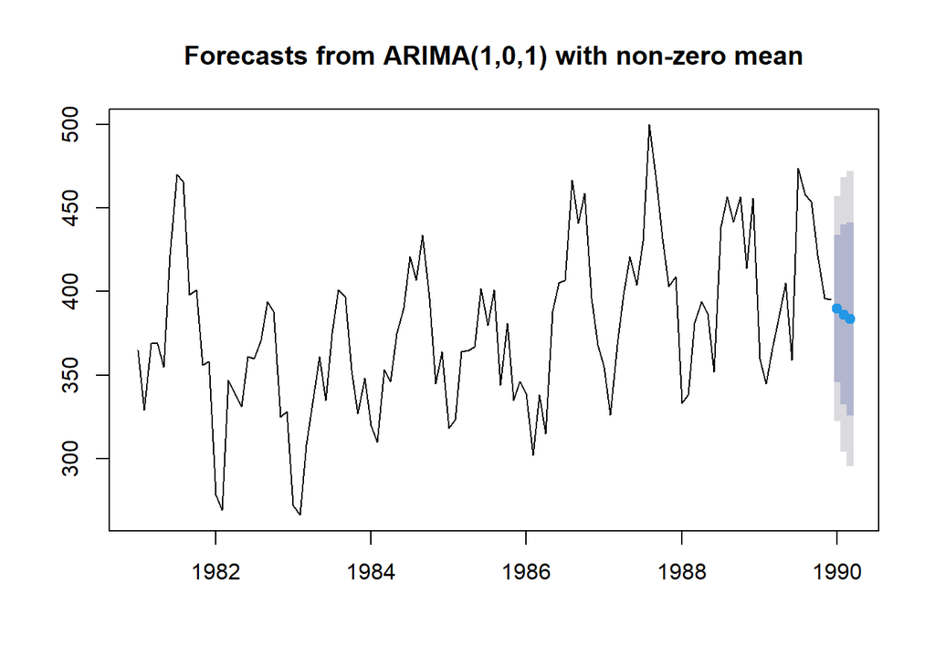

```r
fatal.ARIMA<-arima(fatal,order=c(1,0,1))
fatal.ARIMA.forecast<-forecast(fatal.ARIMA,3)
plot(fatal.ARIMA.forecast)
```

```r
Box.test(fatal.ARIMA.forecast$residuals,lag=20,type="Ljung-Box")
```

```
##
##  Box-Ljung test
##
## data:  fatal.ARIMA.forecast$residuals
## X-squared = 90.895, df = 20, p-value = 5.167e-11
```

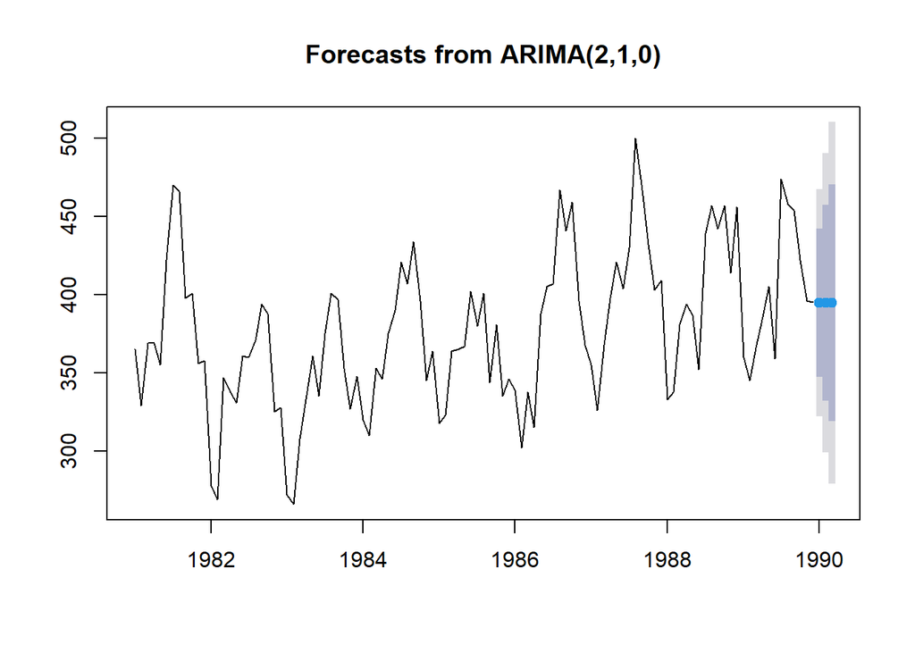

```r
fatal.ARIMA2<-arima(fatal,order=c(2,1,0))
fatal.ARIMA.forecast2<-forecast(fatal.ARIMA2,3)
plot(fatal.ARIMA.forecast2)
```

```r
Box.test(fatal.ARIMA.forecast2$residuals,lag=20,type="Ljung-Box")
```

```
##
##  Box-Ljung test
##
## data:  fatal.ARIMA.forecast2$residuals
## X-squared = 96.135, df = 20, p-value = 6.153e-12
```

```r
accuracy(fatal.HW.forecast)
```

```
##                  ME    RMSE      MAE       MPE     MAPE      MASE       ACF1
## Training set 3.0683 27.9673 21.91252 0.6885658 5.915386 0.7534392 0.06080917
```

```r
accuracy(fatal.ARIMA.forecast)
```

```
##                     ME     RMSE      MAE        MPE     MAPE      MASE
## Training set 0.1169516 34.46076 27.05858 -0.8299113 7.324913 0.9303809
##                     ACF1
## Training set 0.006997613
```

```r
accuracy(fatal.ARIMA.forecast2)
```

```
##                     ME     RMSE      MAE        MPE     MAPE     MASE
## Training set 0.3177569 36.92407 29.36964 -0.4634003 7.891475 1.009844
##                      ACF1
## Training set -0.000207661
```

As seen, the HoltWinters does better in forecasting than two ARIMA, so we can use HoltWinters to forecast Fatal Accidents for the first three months of the year 1990

```r
fatal.HW.forecast
```

```
##          Point Forecast    Lo 80    Hi 80    Lo 95    Hi 95
## Jan 1990       330.2327 294.4205 366.0449 275.4627 385.0028
## Feb 1990       319.5592 280.5962 358.5222 259.9705 379.1479
## Mar 1990       356.4532 314.4025 398.5039 292.1422 420.7642
```

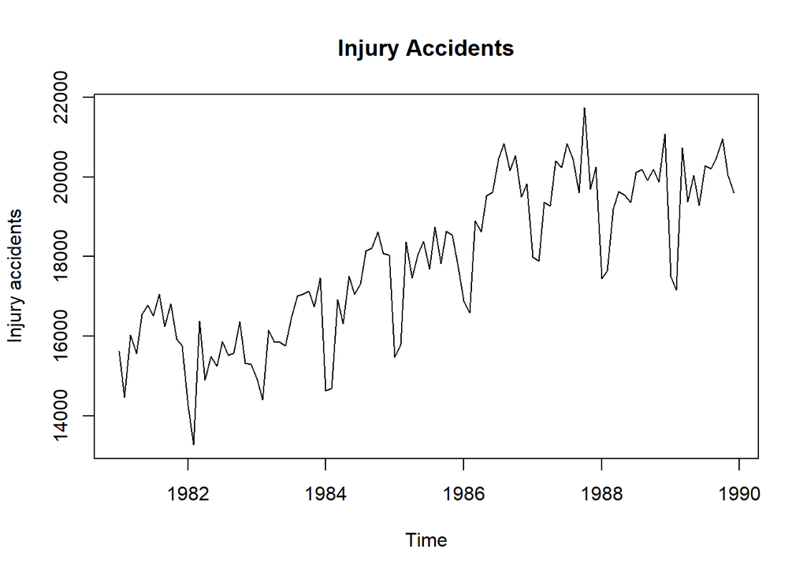

```r
injury<-ts(accidents$Injury_Acc,start=c(1981,1),frequency=12)
plot.ts(injury,main="Injury Accidents",ylab="Injury accidents",xlab="Time")
```

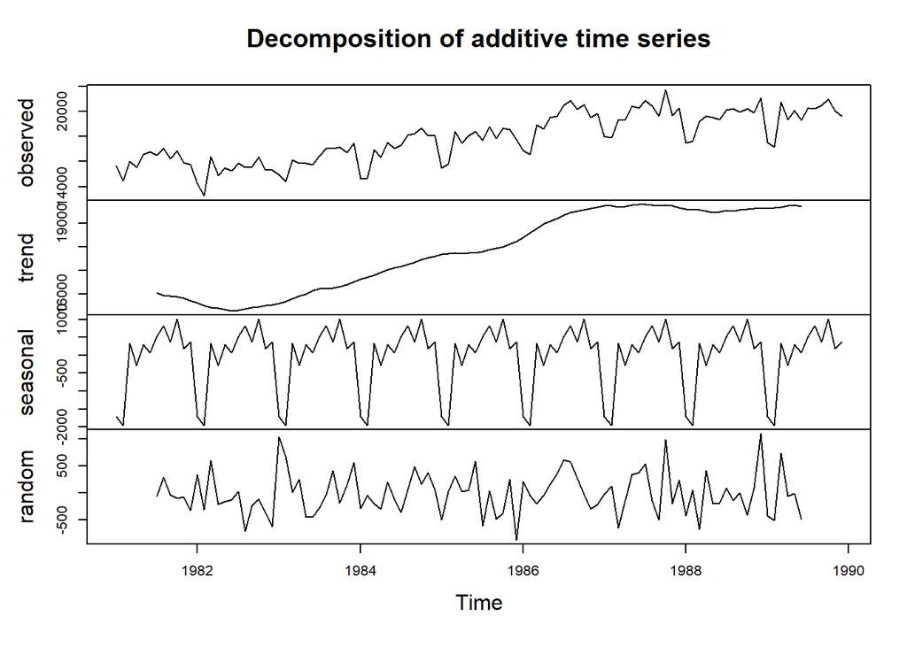

```r
injurycomponents<-decompose(injury)
plot(injurycomponents)
```

We can see fatal accidents have both trend and seasonality, so I will forecast from HoltWinters with both.

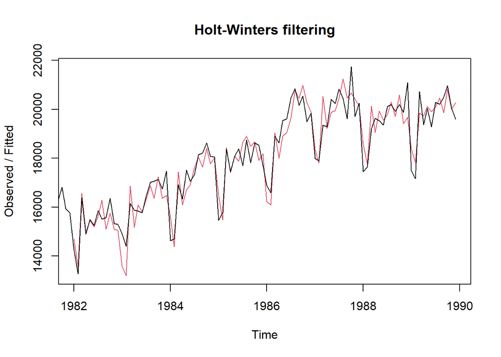

```r
injury.HW<- HoltWinters(injury)
plot(injury.HW)
```

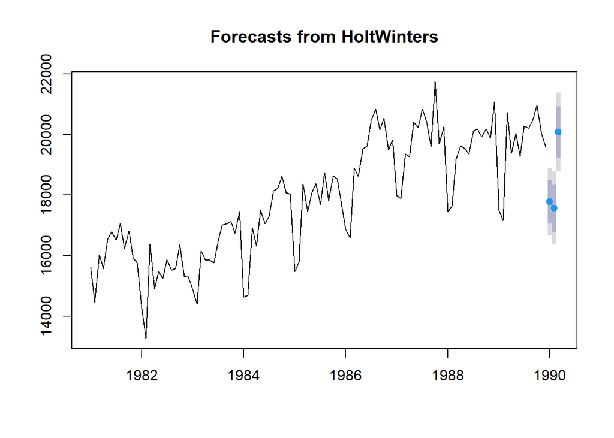

```r
injury.HW.forecast<-forecast(injury.HW,3)
plot(injury.HW.forecast)
```

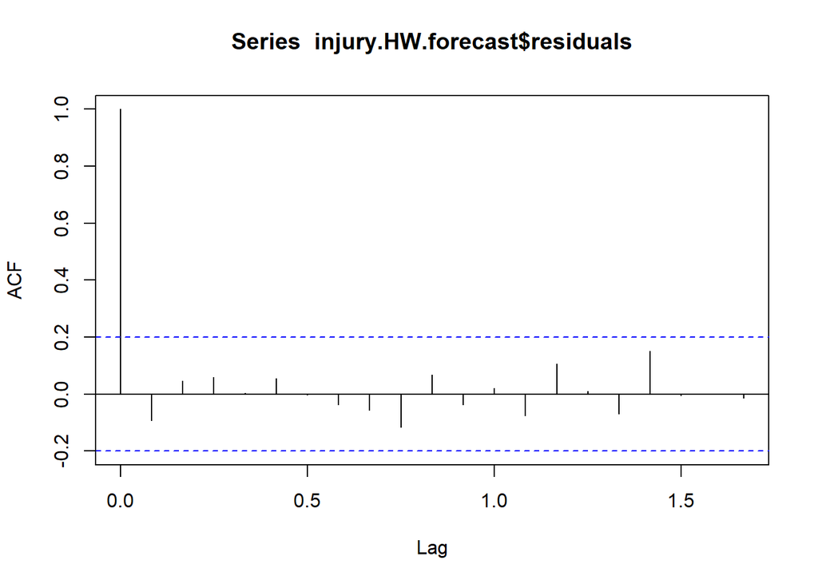

```r
acf(injury.HW.forecast$residuals, lag.max=20, na.action = na.contiguous)
```

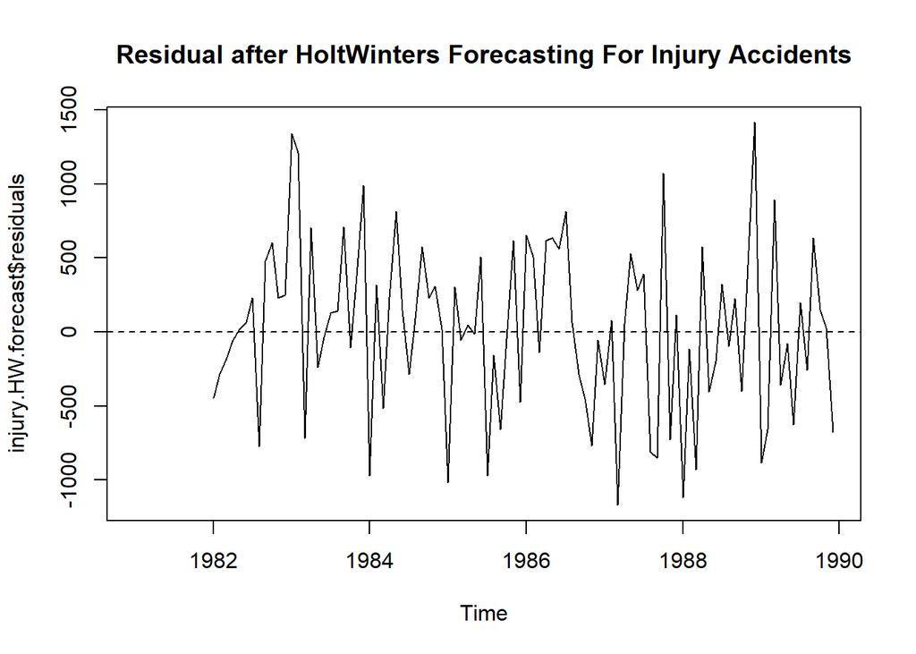

```r
plot.ts(injury.HW.forecast$residuals, main="Residual after HoltWinters Forecasting For Injury Accidents")
abline(h=0,lty=2)
```

```r
Box.test(injury.HW.forecast$residuals,lag=20,type="Ljung-Box")
```

```
##
##  Box-Ljung test
##
## data:  injury.HW.forecast$residuals
## X-squared = 9.6338, df = 20, p-value = 0.9743
```

### Compare with ARIMA

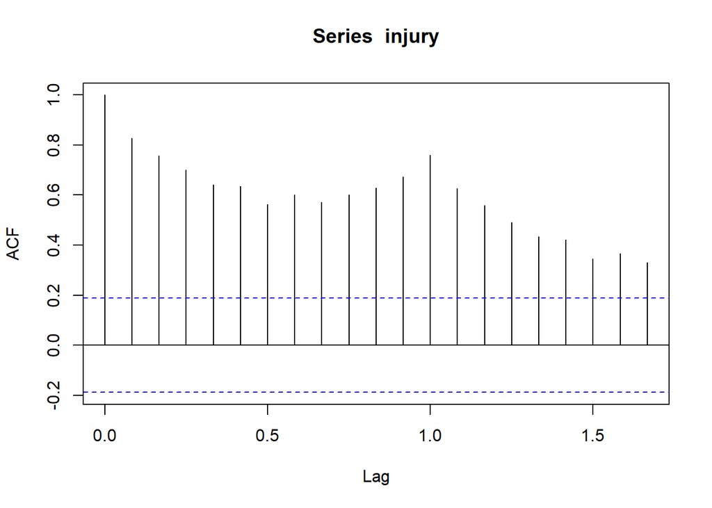

```r
acf(injury, lag.max=20)
```

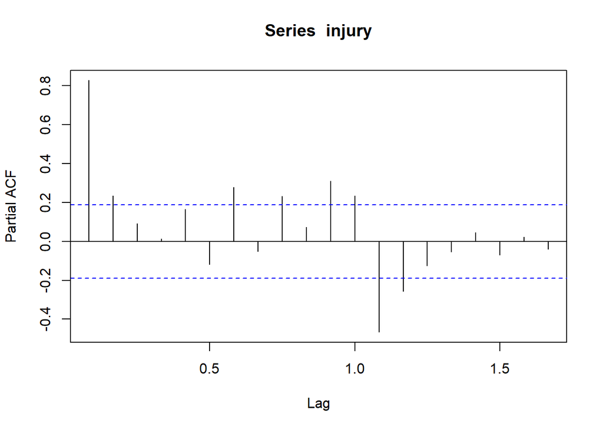

```r
pacf(injury, lag.max=20)
```

```r
auto.arima(injury)
```

```
## Series: injury
## ARIMA(3,0,0)(2,1,0)[12]
##
## Coefficients:
##          ar1     ar2     ar3     sar1     sar2
##       0.3506  0.2750  0.3146  -0.5717  -0.4232
## s.e.  0.1002  0.1023  0.1007   0.1063   0.1105
##
## sigma^2 estimated as 364292:  log likelihood=-752.27
## AIC=1516.54   AICc=1517.48   BIC=1531.93
```

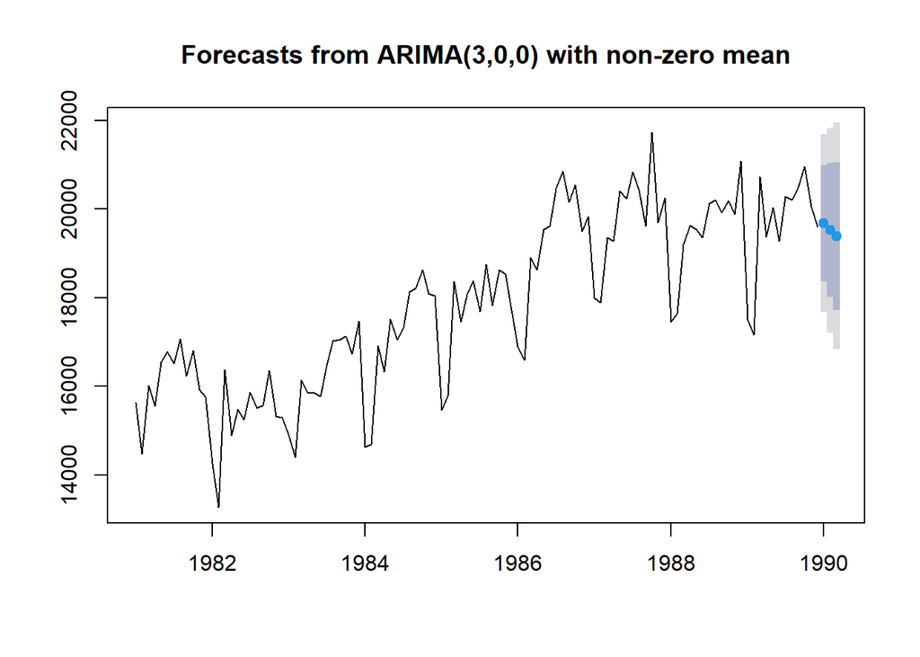

```r
injury.ARIMA<-arima(injury,order=c(3,0,0))
injury.ARIMA.forecast<-forecast(injury.ARIMA,3)
plot(injury.ARIMA.forecast)
```

```r
Box.test(injury.ARIMA.forecast$residuals,lag=20,type="Ljung-Box")
```

```
##
##  Box-Ljung test
##
## data:  injury.ARIMA.forecast$residuals
## X-squared = 84.334, df = 20, p-value = 7.13e-10
```

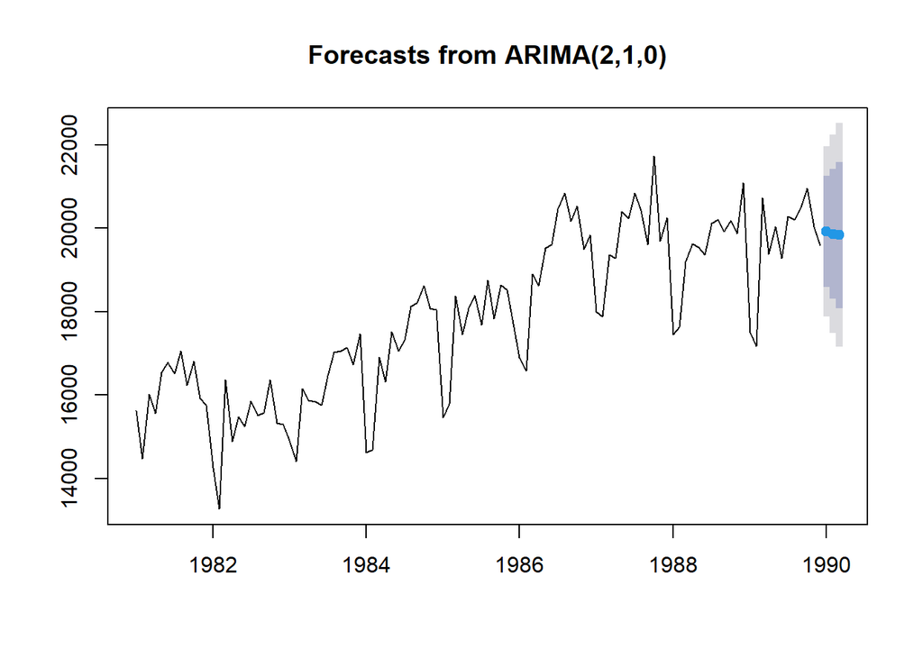

```r
injury.ARIMA2<-arima(injury,order=c(2,1,0))
injury.ARIMA.forecast2<-forecast(injury.ARIMA2,3)
plot(injury.ARIMA.forecast2)
```